# Week 5 Slides

## Sequence Alignment

- Reads aligned to a reference sequence form a distribution of read counts across all locations in the reference sequence
- Any given reference sequence location, or *locus*, has zero or more reads that align to it
- The number of reads aligning to a given locus is called the *read count*
- The read count is proportional to the copy number of molecules in the sample that correspond to that locus
- Read counts from all genes in a reference genome form *count data*

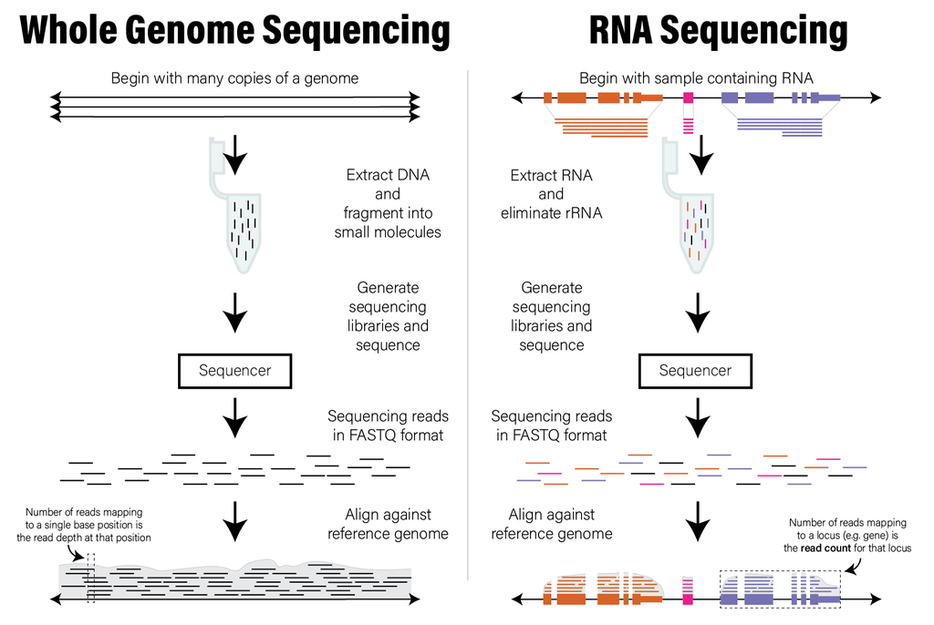

## Count Data

- The *read counts* that align to each locus of a genome form a distribution
- Count data have two important properties:
  - **Count data are integers**
  - **Counts are non-negative**
- *count data are not normally distributed*

## RNASeq

- RNA sequencing (RNASeq) digitizes the RNA molecules in a sample
- Short reads (~100-300 nucleotides long) represent RNA fragments from longer transcripts
- RNA molecules are (in principle) sequenced in proportion to their relative copy number in the original sample
- Each sequencing dataset has a total number of reads called *library size*
- Relative copy number means *absence of evidence is not evidence of absence*
  - i.e. count of zero does *not necessarily mean* no molecules

## RNASeq Gene Expression Data

- When aligned, reads are counted using a *reference annotation* that defines locations of genes in the genome
- For a single sample, output is a vector of read counts for each gene in the annotation
- Genes with no reads mapping to them will have a count of zero
- All others will have a read count of one or more;
- Complex multicellular organisms have on the order of thousands to tens of thousands of genes

## The Counts Matrix

- Read counts from multiple samples of genes using the same annotation are usually concatenated into a *counts matrix*
- Counts matrix usually has genes as rows and samples as columns (not tidy!)
- Usually in `csv` or `tsv` (tab separated) format
- These counts are from O’Meara et al 2014

```r
counts <- read_tsv("verse_counts.tsv")
```

## Example Counts Matrix

```r
counts
```

```
## # A tibble: 55,416 × 9
##    gene                  P0_1  P0_2  P4_1  P4_2  P7_1  P7_2  Ad_1  Ad_2
##    <chr>                <dbl> <dbl> <dbl> <dbl> <dbl> <dbl> <dbl> <dbl>
##  1 ENSMUSG00000102693.2     0     0     0     0     0     0     0     0
##  2 ENSMUSG00000064842.3     0     0     0     0     0     0     0     0
##  3 ENSMUSG00000051951.6    19    24    17    17    17    12     7     5
##  4 ENSMUSG00000102851.2     0     0     0     0     1     0     0     0
##  5 ENSMUSG00000103377.2     1     0     0     1     0     1     1     0
##  6 ENSMUSG00000104017.2     0     3     0     0     0     1     0     0
##  7 ENSMUSG00000103025.2     0     0     0     0     0     0     0     0
##  8 ENSMUSG00000089699.2     0     0     0     0     0     0     0     0
##  9 ENSMUSG00000103201.2     0     0     0     0     0     0     0     1
## 10 ENSMUSG00000103147.2     0     0     0     0     0     0     0     0
## # … with 55,406 more rows
```

## Analyzing Counts Data

There are typically three steps when analyzing a RNASeq count matrix:

1. **Filter genes that are unlikely to be differentially expressed.**
2. **Normalize filtered counts to make samples comparable to one another.**
3. **Differential expression analysis of filtered, normalized counts.**

## Filtering Counts

- Genes not detected in any sample (counts are zero) should not be considered
- Genes with very low counts are not likely to be informative
- Eliminating these genes from consideration reduce multiple hypothesis testing burden later
- General approach: set read count criteria to filter out genes

## Filtering Undetected Genes

- Genes not detected in any sample should be filtered

```r
nonzero_genes <- rowSums(counts[-1])!=0
filtered_counts <- counts[nonzero_genes,]
slice_head(filtered_counts, n=5)
```

```
## # A tibble: 5 × 9
##   gene                  P0_1  P0_2  P4_1  P4_2  P7_1  P7_2  Ad_1  Ad_2
##   <chr>                <dbl> <dbl> <dbl> <dbl> <dbl> <dbl> <dbl> <dbl>
## 1 ENSMUSG00000051951.6    19    24    17    17    17    12     7     5
## 2 ENSMUSG00000102851.2     0     0     0     0     1     0     0     0
## 3 ENSMUSG00000103377.2     1     0     0     1     0     1     1     0
## 4 ENSMUSG00000104017.2     0     3     0     0     0     1     0     0
## 5 ENSMUSG00000103201.2     0     0     0     0     0     0     0     1
```

## Filtering Very Low Count Genes

- Genes with fewer than 2 reads across all samples filtered

```r
nonzero_genes <- rowSums(counts[-1])>=2
filtered_counts <- counts[nonzero_genes,]
slice_head(filtered_counts, n=5)
```

```
## # A tibble: 5 × 9
##   gene                   P0_1  P0_2  P4_1  P4_2  P7_1  P7_2  Ad_1  Ad_2
##   <chr>                 <dbl> <dbl> <dbl> <dbl> <dbl> <dbl> <dbl> <dbl>
## 1 ENSMUSG00000051951.6     19    24    17    17    17    12     7     5
## 2 ENSMUSG00000103377.2      1     0     0     1     0     1     1     0
## 3 ENSMUSG00000104017.2      0     3     0     0     0     1     0     0
## 4 ENSMUSG00000102331.2      5     8     2     6     6    11     4     3
## 5 ENSMUSG00000025900.14     4     3     6     7     7     3    36    35
```

## Filtering by Non-zero Sample Counts

- Statistical procedures don’t work with too many zeros
- Small read counts may indicate very lowly abundant but biologically relevant genes
- Can filter genes based on *number of non-zero sample counts*
  - e.g. Filter out genes if they have zero counts in more than half of samples

## Filtering by Non-zero Sample Counts

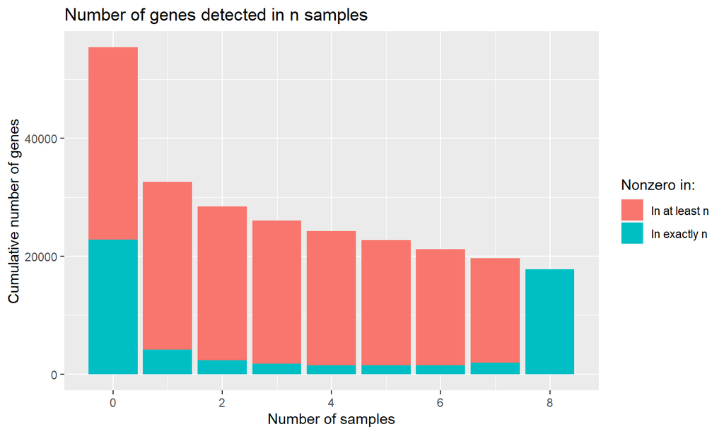